# Assignment 3

December 7, 2023

Higher education in the United States serves as a gateway to elevated salaries, expansive networks that offer both emotional and professional support, and serves as a platform for personal growth and discovery. Despite these valuable benefits, systemic issues pose barriers to accessibility, and the prestige associated with universities can exacerbate disparities between individuals. In recognition of these challenges, this report delves into two inquiries about research institutions, aiming to shed light on aspects of their qualities.

### I. Analysis of Ivy League Universities:

Leveraging data acquired from a Wikipedia article on [research insitutions](https://en.wikipedia.org/wiki/List_of_research_universities_in_the_United_States) the [Shanghai Ranking Consultancy](https://www.shanghairanking.com/), the [ProPublica API](https://projects.propublica.org/nonprofits/api) and the `tidy census` package, the analytical framework examines four relationships (all variables related to money are in USD):

#### Ranking Dynamics:

- Average university ranking across 2003, 2013, and 2023 vs. Average rankings in Economics, Political Science, and Sociology in 2023

#### Financial Landscape:

- Average university ranking vs. Endowment per student

#### Local vs. University Economic Considerations:

- Endowment per student vs. Median household income of the county in which the university is situated across 2015 and 2020
- Revenue per student across the years 2015 - 2020 vs. Median household income of the county in which the university is situated in the same time period as above

### II. Examination of Geographic Disparities:

The next part of the investigation shifts focus to potential geographic disparities in the distribution of these institutions, the research questions include:

#### Ivy League Concentration Patterns:

- Is there any pattern in the concentration of Ivy League institutions relative to the broader landscape of research institutions in the United States?

#### Private vs. Public Institutions:

- Is there any pattern in how private and public research universities are distributed across the United States?

#### Regional Resource Disparities:

- Are there any regions within the United States that exhibit signs of being under-resourced concerning research universities?

### Data Processing

I stored all the data I collected in a local relational database called `university_data`. In total I am adding 5 related tables to it

```r
#create db and check for its existence
database = 'database/university_data.db' #assign dir to database

db <- dbConnect(RSQLite::SQLite(), database) #connect

file.exists(database) #check
```

```
## [1] TRUE
```

```r
dbDisconnect(db) #disconnect
```

#### Table 1 - `university_details`

`university_details` includes 11 variables.

- **ID** : This is the primary key for the table.
  - “For Air Force Institute of Technology Graduate School of Engineering & Management”, I shortened it to “Air Force Institute of Technology” because the hyperlink on Wikipedia was only on this portion of its name
- **Status** : Identifies whether a university is public or private
- **City** : Identifies the city the university is located in
- **State** : Identifies the state the university is located in
- **links** : Stores the link to the university’s wikipedia page
- **geo_coor** : The geo coordinates for the university
  - If a wiki page only included a city instead of geographical coordinates, I used the geo() function from `tidygeocoder` to find their coordinates based on their city. There were 3 universities that still didn’t return any results so I added their coordinates manually. I thought it was important to do so for our map analysis at the end of this report
- **endowment** : The university’s endowment
  - There were 8 universities that didn’t have endowment data. I decided to keep these values as NA since this variable will not be used in our analysis at the end of this report
- **total_students** : Number of students at the university
  - For data on total students, if the students label didn’t have any data, I added the number of undergrads and post grads on the site to find total number of students. Although 2 universities (Air Force Institute of Technology and University of Akron Main Campus) didn’t have either information. I decided to keep those as NA since these variables will not be used in the analysis at the end of this report
- **is_ivy_league** : Identifies whether a university is an ivy league or not
- **ein** : For Ivy Leagues, provides the Employer’s Identification Number which will be used to gather financial data
- **county_state** : The university’s county concatenated with its state

The function defined below shows how I am checking that my database has the approriate data which I will use for all subsequent checks

```r
check_table <- function(db_dir, table) { # Checks existence of a table
  db <- dbConnect(RSQLite::SQLite(), db_dir) # Connect to the SQLite database

  if (dbExistsTable(db, table)) { # Check if the table exists in the database

    # Query to get the count of rows in the table
    row_query <- paste0("SELECT COUNT(*) FROM ", table)

    row_count <- dbGetQuery(db, row_query) # Execute the row count query

    # Query to get information about columns
    col_names <- dbGetQuery(db, sprintf("PRAGMA table_info(%s)", table))

    num_columns <- nrow(col_names) # Get the number of columns

    dbDisconnect(db) # Disconnect from the database

    return(cat( # Return a concatenated string with information about the table
      table, " exists.\n",
      "It has ",
      row_count$`COUNT(*)`,
      " rows and ",
      num_columns,
      " columns. The column names are:\n",
      paste(col_names$name,
            collapse = ", "),
      "\n"
    ))
  } else {# Return a message indicating that the table does not exist
    dbDisconnect(db) # Disconnect from the database
    return(paste0(table, " does not exist"))
  }
}

check_table(database, "university_details") # Check table
```

```
## university_details  exists.
##  It has  279  rows and  11  columns. The column names are:
##  id, Status, City, State, links, geo_coor, endowment, total_students, is_ivy_league, ein, county_state
```

#### Table 2 - `ivy_league_ranking`

This table contains the national/regional ranking of 8 Ivy League universities according to Shanghai Ranking Consultancy in 2003, 2013 and 2023. The variables include:

- **id** : The full name of the university
- **university_rankgroup** : University name concatenated with the year the ranking is from
- **Rank** : The rank for the university
  - If the ranking was a range I took the midpoint of that range

*Note: The instructions didn’t specify which URL to start at when using R Selenium so I started from the URL’s where the tables initially appear when you click explore on the Shanghai Ranking homepage. This allowed me to reuse code from building Table 1.*

```r
check_table(database, "ivy_league_ranking")
```

```
## ivy_league_ranking  exists.
##  It has  24  rows and  3  columns. The column names are:
##  id, university_rankgroup, Rank
```

#### Table 3 - `ivy_league_subject_ranking`

This table presents the worldwide rankings of the 8 Ivy League institutions across 14 social science subjects in 2023. The variables include:

- **id** : The full name of the university
- **university_rankgroup** : University name concatenated with the subject the ranking is from
- **Rank** : The rank for the university
  - If the ranking was a range I took the midpoint of that range

```r
check_table(database, "ivy_league_subject_ranking")
```

```
## ivy_league_subject_ranking  exists.
##  It has  112  rows and  3  columns. The column names are:
##  id, university_rankgroup, Rank
```

#### Table 4 - `university_financial_data`

Contains financial data from Ivy leagues

- **id** : Full name of the university
- **uni_year** : Name of university concatenated with the year the data is from
  - 6 years in our query didn’t return results which explains why there are less than 88 rows in our table. These years will not be included in our calculations at the end of this report
- **total_revenue** : The total revenue from the specified year
- **total_assets** : The total assets from the specified year

```r
check_table(database, "university_financial_data")
```

```
## university_financial_data  exists.
##  It has  82  rows and  4  columns. The column names are:
##  id, uni_year, total_revenue, total_assets
```

#### Table 5 - `university_county_data`

Contains local economic data from counties where there are Ivy Leagues

- **id** : Full name of the university
- **county** : County the university resides in
- **median_hh_income** : Median household income for the county
- **name_year** : Shortened name of university concatenated with the year the data is from

```r
check_table(database, "university_county_data")
```

```
## university_county_data  exists.
##  It has  16  rows and  4  columns. The column names are:
##  id, county_state, median_hh_income, name_year
```

### Analysis

Now that we have all the relevant data in the database we can begin to explore the relationships in our inquiries

#### Ranking Dynamics

Figure 1 visually demonstrates that as a university’s overall ranking decreases from the top, so does its average ranking in the specific fields of Economics, Political Science, and Sociology during the specified years. For instance, Harvard, with an overall ranking of 1, exhibits an average ranking of 1.6 in these social science subjects, positioning its point in the lower-left quadrant of the graph.

Moreover, an intriguing pattern emerges across these universities (excluding Dartmouth): their overall rankings tend to be higher relative to their average rankings in these particular social science subjects for the given years. This observation could prompt further investigation into the subjects in which these universities excel, potentially contributing to their elevated overall rankings. Moreover, another examination restricted to concurrent years could reveal variations in the interplay between overall rankings and discipline-specific standings.

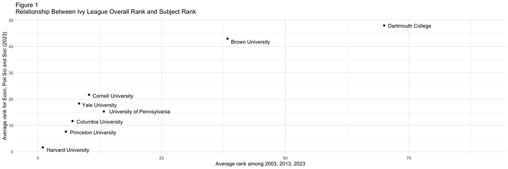

#### Financial Landscape

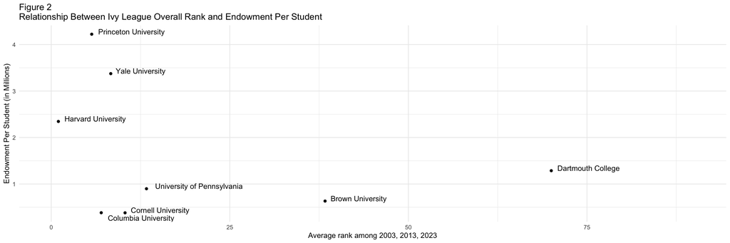

#### Local vs. University Economic Considerations:

Figures 3 and 4 work in harmony, their axes shedding light on the stark disparities between the financial resources of Ivy League universities and the median household income of their respective counties. In the initial plot, the endowment per student, soaring into the millions, starkly contrasts with the modest median household incomes, measured in tens of thousands. For example, Dartmouth has an endowment per student of approximately 1.2 million while its county, Grafton, has a median household income of approximately $62,000. Similarly, the second plot illustrates that revenue per student reaches hundreds of thousands. Remarkably, both graphs share a relatively confined axis range, emphasizing the consistent characteristics within these two variables across this cluster of universities.

In comparison, Yale, Princeton, and Harvard appear to lead in revenue and endowment per students, while Columbia, Dartmouth, Cornell, and Brown lag behind. The University of Pennsylvania stands out, notably aligning with Yale, Princeton, and Harvard in revenue per student, presenting a unique profile compared to their endowment.

Yet, while these visualizations provide valuable insights into the financial dynamics, they don’t fully capture the nuanced tensions that unfold in the interactions between these universities and the local communities. Take, for instance, the county of the University of Pennsylvania, which boasts the lowest median household income among the counties in our analysis. Here, a grassroots movement called [Save the UC Townhomes Coalition](https://savetheuctownhomes.com/about/) has emerged, challenging the University of Pennsylvania (as well as other neighboring universities) for its alleged role in the destruction and forced displacement of Black communities. This example is but a glimpse into the broader issue, as each university in our analysis grapples with similar disparities and community tensions.

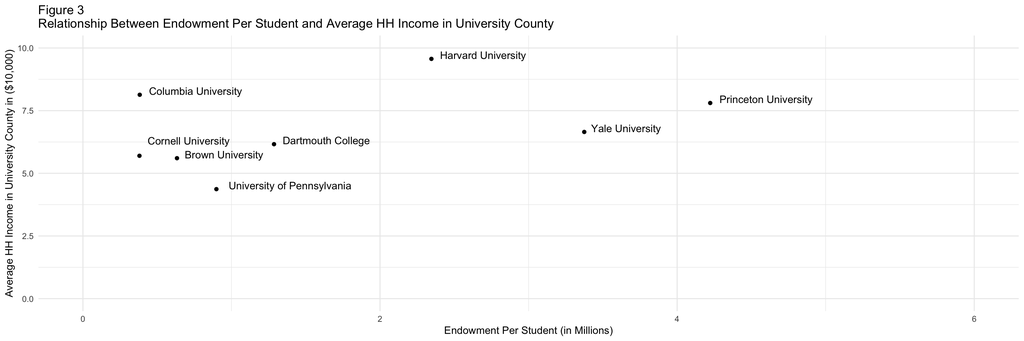

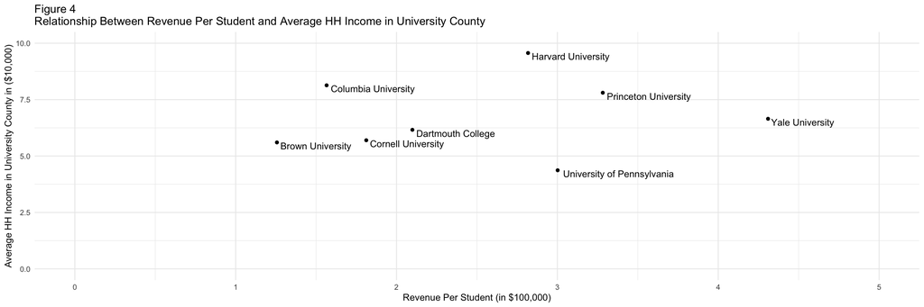

Finally, we will look toward our second set of queries with Figure 5

#### Ivy League Concentration Patterns:

The geographical distribution depicted in Figure 5 highlights that the majority of Ivy League institutions are situated clustered together in the northeastern region of the United States along the coast. This stands in contrast to the broader landscape of research institutions, which exhibit a more dispersed presence across the entire country.

#### Private vs. Public Institutions:

As shown by the blue and yellow transparent dots in Figure 5 the eastern half of the United States is more densely populated with research institutions compared to the Western half (other than at the two coastal cities in California). Overall there appears to be more public institutions than private

#### Regional Resource Disparities:

The western part of Texas up until the Eastern part of California and North of this seem to exhibit signs of being under resourced. However, the majority of research universities in the area are public.

In conclusion, this report serves as an interesting starting point for further investigation into different aspects of the research institution landscape in the United States. On one hand, further research can be done into the factors that lead Ivy Leagues being ranked at the top and if they take factors like diversity and community engagement into account in their calculations. On the other hand, research can also be done on the geographic disparity of these institutions and why the western half of the United States sees less development of these top institutions and why most of these institutions are public.

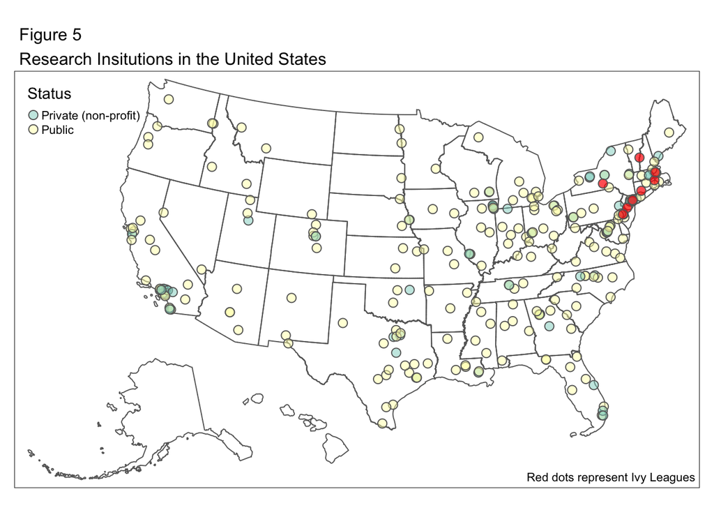

## Appendix: All code in this assignment

```r
knitr::opts_chunk$set(echo = FALSE, warning=FALSE, message=FALSE)
library(RSQLite)
library(rvest)
library(tidyverse)
library(RSelenium)
library(dplyr)
library(httr)
library(tigris)
library(tmap)
library(sf)
library(tidygeocoder)
#create db and check for its existence
database = 'database/university_data.db' #assign dir to database

db <- dbConnect(RSQLite::SQLite(), database) #connect

file.exists(database) #check

dbDisconnect(db) #disconnect

#=========================================================
# Get Helper Functions
#=========================================================
get_all_links <- function(html){ # Gets all links from the input HTML

  # Extract all hyperlink elements from the provided HTML
  link_elements <- html %>%
    html_elements(css = "a")

  # Extract the text content from the extracted urls.
  link_texts <- link_elements %>% html_text()

  # Create a list containing the elements and their corresponding texts
  link_data <- list("link_elements" = link_elements,
                    "link_texts" = link_texts)

  # Return the created list containing link_elements and link_texts.
  return(link_data)
}

get_full_links <- function(link_data_lst, strings, url_prefix) {
  filtered_links <- strings %>%
    map_chr(~ { # map_chr iterates over each string

      # Finds the corresponding HTML element
      curr_element <- link_data_lst$link_elements[link_data_lst$link_texts == .][1]

      # Extracts the url_suffix for html element
      curr_partial_url <- curr_element %>% html_attr("href")

      # Combines the prefix with the suffix to get the full url
      paste(url_prefix, curr_partial_url, sep = "")
    })

  return(filtered_links)
}

get_txt_by_labels <- function(x, labels, data) {

  x_plural <- paste0(x, "s")  # Create a plural version of x

  if (x %in% labels) {  # if x is present in labels
    text <- data[labels == x]  # Retrieve text corresponding to x
  }
  # Check plural
  else if (x_plural %in% labels) {  # Else, if x_plural is present in labels
    text <- data[labels == x_plural]  # Retrieve text corresponding to x_plural
  }
  else {
    return(NA)  # Return NA if neither x nor x_plural is present in labels
  }

  # Return first string
  return(text[1])
}

#=========================================================
# Cleaning Functions
#=========================================================
clean_geo_data <- function(df) {
  df <- df %>%
    mutate( # Mutate the geo_coor column
      geo_coor = df$geo_coor %>%

        # Remove everything before the final slash
        sub(".*/", "", .) %>%

        # Remove everything after brackets
        sub("\\[.*", "", .) %>%

        # Remove whitespace
        str_squish()

    ) %>%

    # Prepare city names to find coordinates

    # If "US" is abbreviated, no results will be returned; lengthening it here.
    mutate(geo_coor = gsub("U.S.", "United States", geo_coor),

           # Full name of this city doesn't return results; shortening it here
           geo_coor = gsub(" and Rochester Hills", "", geo_coor))

  # Find the coordinates for universities that didn't have one on wikipedia
  df_filtered <- df %>%

    # Create a new dataframe where geo_coor starts with a letter
    filter(grepl("^[A-Za-z]", geo_coor))

  # Use the geo() function to obtain coordinates
  geo_coded_results <- geo(df_filtered$geo_coor,
                           method = "osm",
                           full_results = TRUE)

  # Mutate the geo_coded_results to concatenate latitude and longitude
  geo_coded_results <- geo_coded_results %>%
    rowwise() %>%

    #ensuring coordinates are in correct order
    mutate(geo_coor = paste(c(lat, long), collapse = ";"))

  # Mutatedf to add the coordinates that were missing from Wikipedia
  df <- df %>%
    mutate(
      geo_coor = if_else(

        # If the city matches in both df's
        geo_coor %in% geo_coded_results$address,

        # Add the coordinate
        geo_coded_results$geo_coor[match(geo_coor, geo_coded_results$address)],

        # Otherwise return the coordinate we already have
        geo_coor
      ),

      # Address edge cases

      # Remove edge case where city is still in coordinates
      geo_coor = gsub(" Madrid, Spain", "", geo_coor),

      # Manually add geo coordinates for those that could not be found
      geo_coor = ifelse(name == "Loyola Marymount University",
                        "33.9692;-118.4189", geo_coor),
      geo_coor = ifelse(name == "University of Akron Main Campus",
                        "41.0754;-81.5123", geo_coor),
      geo_coor = ifelse(name == "University of Tennessee",
                        "35.9544;83.9295", geo_coor)
    )

  # Return the modified dataframe
  return(df)
}

clean_student_data <- function(df) {
  df <- df %>%

    mutate(  # Add new columns and modify existing ones

      undergrad = undergrad %>%  # Process the 'undergrad' column
        gsub(" .*", "", .) %>%  # Remove everything after the first white space
        sub("\\[.*", "", .) %>%  # Remove everything after brackets
        gsub("\\D", "", .) %>%  # Keep only digits
        as.numeric() %>% # Convert the result to numeric
        replace(is.na(.), 0), # Replace NA's with 0's

      postgrad = postgrad %>%  # Process the 'postgrad' column
        gsub(" .*", "", .) %>%  # Remove everything after the first white space
        sub("\\[.*", "", .) %>%  # Remove everything after brackets
        gsub("\\D", "", .) %>%  # Keep only digits
        as.numeric() %>% # Convert the result to numeric
        replace(is.na(.), 0), # Replace NA's with 0's

      total_students = total_students %>%  # Process the total_students column
        gsub(" .*", "", .) %>%  # Remove everything after the first white space
        sub("\\[.*", "", .) %>%  # Remove everything after brackets
        gsub("\\D", "", .) %>%  # Keep only digits
        as.numeric() %>% # Convert the result to numeric
        replace(is.na(.), 0),  # Replace NA's with 0's

      # Add under and post grad students together
      sum_students = undergrad + postgrad,
```

```r
      # If we didn't get any data on total students, add sum_students
      total_students = ifelse(total_students==0,
                              sum_students,
                              total_students)) %>%

    select(-undergrad, -postgrad, -sum_students) %>% # Drop unneeded cols

  return(df)
}

clean_endowment_data <- function(df){ # Cleans endowment data
  df <- df %>%
    # Remove everything after open parenthesis
    mutate(endowment = endowment %>% sub("\\(.*", "", .) %>%

             # Remove everything after open brackets
             sub("\\[.*", "", .)%>%

             # One entry had US in it, remove it
             gsub("US", "", .) %>%

             # Remove trailing whitespace
             str_squish(.) %>%

             # Remove dollar signs
             gsub("\\$", "", .) %>%

             # Lower the case so millions and billions will be comparable
             tolower() %>%
             gsub(' billion', 'e9', .) %>%
             gsub(' million', 'e6', .) %>%

             # Remove the commas for endowments in correct format
             gsub("\\,", "", .) %>%

             # Format endowment as numeric, removing scientific notation
             format(as.numeric(.), scientific = FALSE) %>%

             # Convert to numeric
             as.numeric()
    )

  return(df)
}


clean_social_science_data <- function(social_science_data){
  ss_split <- strsplit(social_science_data, "")[[1]]   # Split each char

  current_word <- "" # Set the current word
  result <- c() # The results will be saved here
  last_char_space <- FALSE # Flag to indicate whether last char was a space

  for (char in ss_split){# Loops through each char to create appropriate words
    if (current_word == "Library & Information Scienc"){ # Account for final word
      current_word <- paste0(current_word, "e") # Add the last char
      result <- c(result, current_word) # Add it to the list
    }
    else if (last_char_space){ # If a space exists, char is a part of the curr word
      current_word <- paste0(current_word, char)
      last_char_space <- FALSE # Lower flag since we have added our space
    }
    else if (char == " ") { # If a space exists, char is a part of the curr word
      current_word <- paste0(current_word, char)
      last_char_space <- TRUE # Raise flag
    }
    else if (char == toupper(char)){ # If the char is a capital letter, new word
      if (current_word != ""){ # Don't add a word if its empty
        result <- c(result, current_word) # Add previous word to result
        counter <- counter + 1
      }
      current_word <- "" # Clear the current word
      current_word <- paste0(current_word, char) # Add letter to current word
    }
    else{
      current_word <- paste0(current_word, char)
    }
  }
  return(result)
}

clean_rankings <- function(df, rank_col, group_vars){
  df <- df %>%
    mutate( # Create a new column 'rank_split'
      rank_split = ifelse(grepl("-", .data[[rank_col]]), # If the rankings contain hyphen

                          # Split rankings and convert to numeric
                          lapply(strsplit(.data[[rank_col]], "-"), as.numeric),

                          # Else convert rank to numeric
                          as.numeric(.data[[rank_col]]))) %>%

    # Unnest the 'rank_split' column to create separate appropriate ranks
    unnest(rank_split) %>%

    # Group the data by the specified variables in group_vars.
    group_by(across(all_of(group_vars))) %>%

    summarise(
      # If hyphen is present
      midpoint = ifelse(any(grepl("-", rank_col)),

                        # Round the mean of 'rank_split'
                        round(mean(rank_split)),

                        # Otherwise, use the numeric value of 'rank_split'.
                        as.numeric(rank_split))
    ) %>%

    # Ungroup the data to remove grouping.
    ungroup() %>%

    # Select all columns except the original rank_col
    select(-{{rank_col}}) %>%

    # Rename the 'midpoint' column to 'Rank'.
    dplyr::rename(Rank = midpoint)

  # Return the modified data frame.
  return(df)
}

clean_names <- function(df, ivy_data, additional_info) {
  df$short_name <- NA

  for (name in ivy_data$uni_name) { # For each uni name in the Ivy League data

    # Find matching rows in the data frame based on the university name
    matching_rows <- grep(name, df$Institution)

    # If there is a match, add the university name to the 'short_name' column
    if (length(matching_rows) > 0) {
      df$short_name[matching_rows] <- name
    }
  }

  # If additional information is "year," clean the 'year' column
  if (additional_info == "year") {
    df <- df %>%
      mutate(year = gsub("\\D", "", year)) # Update 'year' column to just a year
  }

  df <- df %>%
    mutate(

      # Clean 'Institution' name by removing characters after newline
      id = sub("\\\n.*", "", Institution),

      # Concatenate 'short_name' and 'additional_info'
      university_rankgroup = paste0(short_name, "-", .data[[additional_info]])
    ) %>%

    # Ungroup to allow removal of unneeded columns
    ungroup() %>%

    # Select relevant columns
    dplyr::select(id, university_rankgroup, Rank) %>%

    # Drop empty rows
    drop_na(id)

  return(df)
}

#=========================================================
# Generate Functions
#=========================================================
#creates list with static selectors
generate_static_selectors <- function(element_types, element_path){
  lst <- list() # Create list

  lst <- append(lst, element_path) # Add element path to the list

  names(lst) <-element_types # Name the element

  return (lst)
}

#=========================================================
# Exercise 2 Functions
#=========================================================
# A web scraping function that constructs a table of all R1 (Very High Research
# Activity) and R2 (High Research Activity) Research Universities in the USA
get_research_data <- function(url){
  html_content <- read_html(url)   # read html
```

```r
  #get both tables
  v_high_research <- html_elements(html_content, css = ".wikitable")[[1]] %>%
    html_table(fill=TRUE)
  high_research <- html_elements(html_content, css = ".wikitable")[[2]]  %>%
    html_table(fill=TRUE)

  #remove empty cols in high_research
  high_research <- high_research %>% select(-where(~all(is.na(.)))) %>%
    #this uni is hyper linked only on a part of its name
    mutate(Institution = ifelse(Institution ==
                                  "Air Force Institute of Technology Graduate School of Engineering & Management",
                                "Air Force Institute of Technology", Institution))

  all_uni_data <- rbind(v_high_research, high_research) #combine tables

  link_data<- get_all_links(html_content) #get all urls on the webpage

  # Get the urls for the institutions we need
  url_prefix <- 'https://en.wikipedia.org'
  uni_links <- get_full_links(link_data, all_uni_data$Institution, url_prefix)

  # Add uni links to main table
  all_uni_data <- all_uni_data %>% mutate(links = uni_links)

  return(all_uni_data)
}

# A webscraping function that navigates to the dedicated Wikipedia page for each
# university, and captures three additional variables: geo coordinates,
# total students and endowment
fetch_uni_details <- function(uni_links, uni_names){
  #create a tibble to store university data
  uni_data <- tibble(name = uni_names,
                       geo_coor = NA,
                       endowment= NA,
                       undergrad = NA,
                       postgrad = NA,
                     total_students= NA)

  # For every university, get the data
  for (curr_name in uni_names) {
    #get the link for the current university and read the html
    curr_link <- uni_links[uni_names == curr_name]
    curr_html <- read_html(curr_link)

    # Get all the labels and their data from the html
    labels <- curr_html %>% html_elements(css = ".infobox-label") %>% html_text()
    data <- curr_html %>% html_elements(css = ".infobox-data") %>% html_text()

    # If the label is location, get its data
    uni_data[uni_data$name == curr_name, "geo_coor"] <-
      get_txt_by_labels("Location", labels, data)

    # If the label is endowment, get its data
    uni_data[uni_data$name == curr_name, "endowment"] <-
      get_txt_by_labels("Endowment", labels, data)

    # If the label is undergraduate, get its data
    uni_data[uni_data$name == curr_name, "undergrad"] <-
      get_txt_by_labels("Undergraduate", labels, data)

    # If the label is postgraduate, get its data
    uni_data[uni_data$name == curr_name, "postgrad"] <-
      get_txt_by_labels("Postgraduate", labels, data)

    # If the label is students, get its data
    uni_data[uni_data$name == curr_name, "total_students"] <-
      get_txt_by_labels("Student", labels, data)



    Sys.sleep(0.5)
  }
  return(uni_data)
}

#=========================================================
# Exercise 3 Functions
#=========================================================
# A web scraping function that collects data on each name in each year
get_uni_ranking <- function(names, years, selector_list, sec = 2){
  # Create results_df
  results_df <- tibble(Institution = NA, rank = NA, year = NA)

  # Start driver
  url <- "https://www.shanghairanking.com/rankings/arwu/2023"
  rD <- rsDriver(browser=c("firefox"),
                 verbose = F,
                 port = netstat::free_port(random = TRUE),
                 chromever = NULL)
  driver <- rD$client
  driver$navigate(url)

  # For each date we are collecting data for
  for (year in names(years)){
    # Go to the drop down menu
    drop_down <- driver$findElement(using = "xpath",
                                    value = selector_list$drop_down)
    # Click it
    drop_down$clickElement()
    # Wait for suggestions
    Sys.sleep(sec)
    # Search for the current date we are collecting data for
    selectelem <- driver$findElement(using = "xpath", value = years[[year]])
    # Click that date
    selectelem$clickElement()

    # Identify the search field for input
    search_box <- driver$findElement(using = "xpath",
                                     value = selector_list$search_box)

    # For each name in uni_names
    for (name in names){
      # Print "getting data for uni_name in date"
      cat("Getting data for ", name, " in ", year, "\n")
      # Send the uni name
      search_box$sendKeysToElement(list(name))

      # Click enter
      search_box$sendKeysToElement(list(key = "enter"))

      Sys.sleep(sec)

      # Now that we have the uni info displayed, scrape the ranking
      res_div <- driver$findElement(using = 'class name', value = 'rk-table')
      # Get the html of the table
      results_html <- read_html(res_div$getElementAttribute('outerHTML')[[1]])
      # Convert it into a table we can use
      results_table <- html_table(results_html)[[1]]

      # Collect everything into one row
      new_row <- results_table %>%
        # This fixes an issue where R is using select from the MASS package
        dplyr::select("Institution", "National/Regional\nRank") %>%
        rename(rank = `National/Regional\nRank`) %>%
        mutate(year = year)

      # Add row to df
      results_df <- rbind(results_df, new_row)

      #clear search bar
      search_box$clearElement()
    }
  }
  driver$close() # Close the driver

  return (results_df)
}

# A webscraping function that collects social science data for each name in
# names and each link in social_science_links
get_uni_ranking_subject_specific <- function(names,
                                             social_science_links, sec = 2){
  results_df <- tibble(Institution = NA, `World Rank` = NA, subject = NA)

  rD <- rsDriver(browser=c("firefox"), verbose = F,
                 port = netstat::free_port(random = TRUE),
                 chromever = NULL)
  driver <- rD$client

  for (subject in names(social_science_links)){
    # Get the link for current subject
    url <- social_science_links[names(social_science_links) == subject]
    # Navigate to its page which has the table information
    driver$navigate(url)
```

```r
    # Identify the search field for input
    search_box <- driver$findElement(using = "xpath",
                                     value = selector_list$search_box)

    # For each name in uni_names
    for (name in names){
      # Print "getting data for uni_name in date"
      cat("Getting data for ", name, "in", subject, "\n")
      # send the uni name
      search_box$sendKeysToElement(list(name))
      # Click enter
      search_box$sendKeysToElement(list(key = "enter"))
      # Wait for suggestions
      Sys.sleep(sec)

      tryCatch(
        {
          # Now that we have the uni info displayed, scrape the ranking
          # Try to find elements
          res_div <- driver$findElement(using = 'class name',
                                        value = 'rk-table')

          results_html <- read_html(res_div$getElementAttribute('outerHTML')[[1]])
          # Convert it into a table we can use
          results_table <- html_table(results_html)[[1]]

          # Collect everything into one df
          new_row <- results_table %>%
            dplyr::select("Institution", "World Rank") %>%
            mutate(subject=subject)

          results_df <- rbind(results_df, new_row)

          # Clear search bar
          search_box$clearElement()
        },
        error = function(e){
          # Handle the NoSuchElement exception
          new_row <- tibble(Institution = name,
                            `World Rank` = NA,
                            subject = subject)
          results_df <<- rbind(results_df, new_row)
          # Clear search bar
          search_box$clearElement()
        }
      )
  }
  }
  driver$close()

  return (results_df)
}
#=========================================================
# Exercise 2a-b Data Processing
#=========================================================
# Get url
url <- "https://en.wikipedia.org/wiki/List_of_research_universities_in_the_United_States"

# Get data for exercise 2a
uni_data <- get_research_data(url)

# Get data for exercise 2b
uni_details <- fetch_uni_details(uni_data$links, uni_data$Institution)

# Clean uni_details
uni_details_clean <- uni_details %>%
  clean_student_data() %>%
  clean_geo_data() %>%
  clean_endowment_data()

# Merge university data together
all_uni_data <- merge(x = uni_data,
                       y = uni_details_clean,
                       by.x = "Institution",
                       by.y = "name",
                       all.x=TRUE) %>%

  # Change the control col to a more descriptive name
  rename(Status = Control)

# Write this df to the database. Allows us access to data without scraping
# in every knit
db <- dbConnect(RSQLite::SQLite(), database) # Connect
dbWriteTable(db, "university_details", all_uni_data) # Write
dbDisconnect(db) # Disconnect
#=========================================================
# Exercise 2c Data Processing
#=========================================================
# Get uni data to add ivy_league information
db <- dbConnect(RSQLite::SQLite(), database) # Connect
all_uni_data <- dbGetQuery(db,
                           "SELECT *
                           FROM university_details") # Conduct query
dbDisconnect(db) # Disconnect

raw_ivy_leagues <- read_csv("ivyleague.csv") # Get file

# Add full names to raw file
ivy_data <- raw_ivy_leagues %>%
  mutate(
    full_name = case_when(
      uni_name == "Penn" ~ "University of Pennsylvania",
      uni_name == "Brown" ~ "Brown University",
      uni_name == "Columbia" ~ "Columbia University",
      uni_name == "Cornell" ~ "Cornell University",
      uni_name == "Dartmouth" ~ "Dartmouth College",
      uni_name == "Harvard" ~ "Harvard University",
      uni_name == "Princeton" ~ "Princeton University",
      uni_name == "Yale" ~ "Yale University",
      TRUE ~ as.character(NA)  # Default case if no match
    )
  )

# Identify Ivy Leagues in the main df and merge ivy_data
main_with_ivy_data <- all_uni_data %>%

  # Create a new column that indicates whether uni is an ivy league
  mutate(is_ivy_league = Institution %in% ivy_data$full_name) %>%

  # Left join with 'ivy_data' selecting needed columns
  left_join(ivy_data %>% select(full_name, ein, county),
            by = c("Institution" = "full_name"))

processed_uni_data <- main_with_ivy_data %>%

  mutate(
    # Get full state name
    full_state_name = state.name[match(State, state.abb)],

    # Combine county with state
    county_state = ifelse(is_ivy_league, paste(county,
                                               full_state_name,
                                               sep = ", "),
                          NA)
  ) %>%

  # Remove specified columns
  select(-county, -full_state_name) %>%

  #Rename Institution to ID
  rename(id = Institution)

#=========================================================
# Write 2a-c into Database
#=========================================================
db <- dbConnect(RSQLite::SQLite(), database) # Connect
dbWriteTable(db, "university_details", processed_uni_data) # Write data
dbDisconnect(db) # Disconnect
check_table <- function(db_dir, table) { # Checks existence of a table
  db <- dbConnect(RSQLite::SQLite(), db_dir) # Connect to the SQLite database

  if (dbExistsTable(db, table)) { # Check if the table exists in the database

    # Query to get the count of rows in the table
    row_query <- paste0("SELECT COUNT(*) FROM ", table)

    row_count <- dbGetQuery(db, row_query) # Execute the row count query

    # Query to get information about columns
    col_names <- dbGetQuery(db, sprintf("PRAGMA table_info(%s)", table))

    num_columns <- nrow(col_names) # Get the number of columns

    dbDisconnect(db) # Disconnect from the database

    return(cat( # Return a concatenated string with information about the table
      table, " exists.\n",
      "It has ",
      row_count$`COUNT(*)`,
      " rows and ",
      num_columns,
      " columns. The column names are:\n",
      paste(col_names$name,
            collapse = ", "),
      "\n"
    ))
  } else {# Return a message indicating that the table does not exist
    dbDisconnect(db) # Disconnect from the database
    return(paste0(table, " does not exist"))
  }
}
```

```r
check_table(database, "university_details") # Check table

#=========================================================
# Exercise 3a Data Processing
#=========================================================
# 3a
# Define types of selectors for Shanghai ranking
shanghai_types <- c("drop_down", "search_box")

# Define XPaths for Shanghai ranking selectors
shanghai_paths <- c('//*[@id="bar-content"]/div[1]/div/div[1]',
                    '//*[@id="content-box"]/div[1]/input')

# Define names for years
year_names <- c("year_2003", "year_2013", "year_2023")

# Define XPaths for year selectors
year_paths <- c('//*[@id="bar-content"]/div[1]/div/div[2]/ul/li[21]',
                '//*[@id="bar-content"]/div[1]/div/div[2]/ul/li[11]',
                '//*[@id="bar-content"]/div[1]/div/div[2]/ul/li[1]')

# Generate static selectors for Shanghai ranking
selector_list <- generate_static_selectors(shanghai_types, shanghai_paths)

# Generate static selectors for years
year_list <- generate_static_selectors(year_names, year_paths)

# Get university rankings using defined selectors and years
uni_rankings <- get_uni_ranking(ivy_data$full_name, year_list, selector_list)

# Clean the obtained rankings data
clean_rank <- clean_rankings(uni_rankings,
                             "rank",
                             c("Institution",
                               "rank",
                               "year"))

# Clean the column names and combine with additional data from ivy_data
uni_rankings_clean <- clean_names(clean_rank, ivy_data, "year")

#=========================================================
# Exercise 3b Data Processing
#=========================================================
# Define the URL to scrape
url = 'https://www.shanghairanking.com/rankings/gras/2023'

# Read the HTML content from the URL
html_content <- read_html(url)

# Extract text content for the 'Social Sciences' category
social_sciences <- html_elements(html_content,
                                 xpath = '//*[@id="__layout"]/div/div[2]/div[2]/div[1]')[[1]] %>%
  html_text()

# Extract labels and data from HTML content
labels <- html_content %>% html_elements(css = ".subject-category") %>%
  html_text()
data <- html_content %>% html_elements(css = ".subject-list") %>%
  html_text()

# Get data specifically for 'Social Sciences'
social_science_data <- get_txt_by_labels("Social Sciences\n", labels, data)

# Clean the social science data
subjects <- clean_social_science_data(social_science_data)

# Get all links on the webpage
all_link_elements <- html_elements(html_content, css = "a")
all_link_texts <- all_link_elements %>% html_text()

# Get the URL for each subject
social_science_links <- c()

# Iterate over each subject in the 'subjects' vector
for (subject in subjects){

  # Find the HTML element corresponding to the current subject
  current_subject_element <- all_link_elements[all_link_texts == subject][1]

  # Extract the partial URL from the HTML element
  current_partial_url <- current_subject_element %>% html_attr("href")

  # Combine the base URL with the partial URL to form the complete URL
  current_url <- paste("https://www.shanghairanking.com",
                       current_partial_url,
                       sep = "")

  # Append the current URL to the 'social_science_links' vector
  social_science_links <- append(social_science_links, current_url)
}

# Assign names to the links based on subjects
names(social_science_links) <- subjects

# 3b - Go to each url and get data
subject_ranks <- get_uni_ranking_subject_specific(ivy_data$full_name,
                                                  social_science_links)

# Clean rankings
clean_rank_subjects <- clean_rankings(subject_ranks,
                                      "World Rank",
                                      c("Institution",
                                        "subject",
                                        "World Rank"))

# Clean university names
subject_ranks_clean <- clean_names(clean_rank_subjects,
                                   ivy_data,
                                   "subject")

#=========================================================
# Write 3a-b into Database
#=========================================================
# Write data into database to use later, so we don't have to scrape everytime we knit
db <- dbConnect(RSQLite::SQLite(), database) #connect

dbWriteTable(db, "ivy_league_ranking", uni_rankings_clean)
dbWriteTable(db, "ivy_league_subject_ranking", subject_ranks_clean)

dbDisconnect(db)
check_table(database, "ivy_league_ranking")
check_table(database, "ivy_league_subject_ranking")
#=========================================================
# Exercise 4a Data Processing
#=========================================================
# Create an empty data frame to fill with data from the API
result_df <- data.frame(id = character(),
                        uni_year= character(),
                        total_revenue=integer(),
                        total_assets=integer())

# Loop through each row in the 'ivy_data' data frame
for (i in seq_len(nrow(ivy_data))){

  # Construct the API URL for the current organization using its EIN
  base_url <- paste0('https://projects.propublica.org/nonprofits/api/v2/organizations/',
                     ivy_data$ein[i],
                     ".json")

  # Send a GET request to the API and parse the JSON response
  r <- GET(base_url)
  json <- content(r, "parsed")

  # Loop through each filing with data for the current organization
  for (j in seq_along(json$filings_with_data)) {

    # Extract the tax period year
    tax_prd_yr <- json$filings_with_data[[j]]$tax_prd_yr

    # Extract university year
    uni_year <- paste0(ivy_data$uni_name[raw_ivy_leagues$ein == raw_ivy_leagues$ein[i]],
                       "-",
                       tax_prd_yr)

    # Extract total revenue
    total_revenue <- json$filings_with_data[[j]]$totrevenue

    # Extract total assets
    total_assets <- json$filings_with_data[[j]]$totnetassetend
```

```r
    # Append a new row to 'result_df' with the extracted information
    result_df[nrow(result_df) + 1,] <- c(ivy_data$full_name[i],
                                         uni_year,
                                         total_revenue,
                                         total_assets)
  }
}

#=========================================================
# Exercise 4b Data Processing
#=========================================================
# Read API key from the environment file
readRenviron("apikey.env")
apikey <- Sys.getenv("key")

# Set the Census API key using the retrieved key
census_api_key(apikey)

# Fetch American Community Survey (ACS) data for median HH income in counties for 2015
county_data_2015 <- get_acs(geography = "county",
                            variables = c(medincome = "B19013_001"),
                            year = 2015)

# Fetch ACS data for median HH income in counties for the year 2020
county_data_2020 <- get_acs(geography = "county",
                            variables = c(medincome = "B19013_001"),
                            year = 2020)

# Filter the university data to include only Ivy League institutions
uni_data_filtered <- filter(all_uni_data, is_ivy_league == TRUE)

# Merge filtered uni data with ACS data for median HH income in counties for 2015
ivy_leagues_with_medians_2015 <- merge(x = uni_data_filtered,
                                       y = county_data_2015[ , c("NAME", "estimate")],
                                       by.x = "county_state",
                                       by.y = "NAME",
                                       all.x=TRUE)

# Rename the columns for clarity
ivy_leagues_with_medians_2015 <- ivy_leagues_with_medians_2015 %>%
  rename(
    estimate_2015 = estimate
  )

# Merge the 2015 data with ACS data for median HH income in counties for 2020
ivy_leagues_with_medians_all <- merge(x = ivy_leagues_with_medians_2015,
                                      y = county_data_2020[ , c("NAME", "estimate")],
                                      by.x = "county_state",
                                      by.y = "NAME",
                                      all.x=TRUE)

# Rename the columns for clarity
ivy_leagues_with_medians_all <- ivy_leagues_with_medians_all %>%
  rename(
    estimate_2020 = estimate
  )

# Select relevant columns from the merged data for Ivy League institutions
ivy_leagues_clean <- ivy_leagues_with_medians_all %>%
  dplyr:: select(Institution, county_state, estimate_2015, estimate_2020)

# Reshape the data using pivot_longer to create a tidy format
ivy_leagues_pivot <- ivy_leagues_clean %>%
  pivot_longer(cols = c(estimate_2015, estimate_2020),
               names_to = 'year', values_to = 'median_hh_income') %>%
  # Extract the year and create a new column 'name_year'
  mutate(year_split = sub("estimate_", "", year),
         name_year = paste0(Institution,"-",year_split)) %>%
  dplyr:: select(-year, -year_split) %>%
  # Rename the 'Institution' column to 'id'
  rename(id = Institution)

#=========================================================
# Write 4a-b into Database
#=========================================================
db <- dbConnect(RSQLite::SQLite(), database) # Connect
dbWriteTable(db, "university_financial_data", result_df) # Write
dbWriteTable(db, "university_county_data", ivy_leagues_pivot) # Write
dbDisconnect(db) # Disconnect
check_table(database, "university_financial_data")
check_table(database, "university_county_data")
#=========================================================
# Analysis
#=========================================================
db <- dbConnect(RSQLite::SQLite(), database) # Connect to the database

# Retrieves
# - Average endowment per student
# - Average overall university ranking from all years data we collected data on
# - Average subject ranking in Economics, Political Science, and Sociology
# - Average revenue per student (between 2015-2020)
# - Average household income in the university's county
analysis_df <- dbGetQuery(db,
           "WITH ivys AS (
             SELECT id, endowment/total_students AS endow_per_student
             FROM university_details
             WHERE is_ivy_league = TRUE ),

            ivy_ranking AS (
             SELECT id, AVG(rank) AS avg_rank
             FROM ivy_league_ranking
             GROUP BY id),

            ivy_subject_ranking AS (
             SELECT id, AVG(rank) AS avg_subject_rank
             FROM ivy_league_subject_ranking
             WHERE university_rankgroup LIKE '%Economics%'
             OR university_rankgroup LIKE '%Political Science%'
             OR university_rankgroup LIKE '%Sociology%'
             GROUP BY id
             HAVING AVG(rank) IS NOT NULL),

            ivy_rev AS (
             SELECT university_details.id,
             AVG(university_financial_data.total_revenue/university_details.total_students)
             AS avg_revenue_per_student
             FROM university_details JOIN university_financial_data
             ON university_details.id = university_financial_data.id
             WHERE university_details.is_ivy_league = TRUE
             AND (university_financial_data.uni_year LIKE '%2020%'
             OR university_financial_data.uni_year LIKE '%2019%'
             OR university_financial_data.uni_year LIKE '%2018%'
             OR university_financial_data.uni_year LIKE '%2017%'
             OR university_financial_data.uni_year LIKE '%2016%'
             OR university_financial_data.uni_year LIKE '%2015%')
             GROUP BY university_details.id),

            ivy_hh_income AS (
             SELECT id, AVG(median_hh_income) AS avg_hh_income
             FROM university_county_data
             GROUP BY id)

            SELECT ivys.id,

              (SELECT avg_rank
              FROM ivy_ranking
              WHERE ivy_ranking.id =  ivys.id) AS avg_rank,

              (SELECT avg_subject_rank
              FROM ivy_subject_ranking
              WHERE ivy_subject_ranking.id = ivys.id) AS avg_subject_rank,
```

```r
              endow_per_student,

              (SELECT avg_revenue_per_student
              FROM ivy_rev
              WHERE ivy_rev.id = ivys.id) AS avg_revenue_per_student,

              (SELECT avg_hh_income
              FROM ivy_hh_income
              WHERE ivy_hh_income.id = ivys.id) AS avg_hh_income

            FROM ivys
            ")

dbDisconnect(db) # Disconnect from the database

# Transform analysis df for visualization
# Set variables for large values
one_million <- 1000000
ten_thousand <- 10000
hundred_thousand <- 100000

#Divide variables by constant for increased axis legibility
analysis_df <- analysis_df %>%
  mutate(endow_per_student = endow_per_student/one_million,
         avg_hh_income = avg_hh_income/ten_thousand,
         avg_revenue_per_student = avg_revenue_per_student/hundred_thousand)

# Figure 1
ggplot(analysis_df,
       aes(x=avg_rank, y=avg_subject_rank)) +

  # Add points
  geom_point() +

  # Use a minimal theme
  theme_minimal() +

  # Add labels to data points, jittering their positions slightly
  geom_text(aes(label = id),
            hjust = -0.09,
            vjust = 1,
            position=position_jitter(width=0,height=1)) +

  # Add a main title to the plot
  ggtitle("Figure 1\nRelationship Between Ivy League Overall Rank and Subject Rank") +

  # Label the x-axis
  xlab("Average rank among 2003, 2013, 2023") +

  # Label the y-axis
  ylab("Average rank for Econ, Poli Sci and Soc (2023)") +

  # Set the x-axis limits
  xlim(0, 90)

# Figure 2
ggplot(analysis_df, aes(x=avg_rank, y=endow_per_student)) +

  # Add points
  geom_point() +

  # Use a minimal theme
  theme_minimal() +

  # Add labels to data points, adjusting the psoition of Columbia to avoid overlap
  geom_text(aes(label = id), hjust = -.1,
            vjust = ifelse(analysis_df$id=="Columbia University", 1.5, 0)) +

  # Add a main title
  ggtitle("Figure 2\nRelationship Between Ivy League Overall Rank and Endowment Per Student") +

  # Label the x-axis
  xlab("Average rank among 2003, 2013, 2023") +

  # Label the y-axis
  ylab("Endowment Per Student (in Millions)") +

  # Set the x-axis limits
  xlim(0, 90)

# Figure 3
ggplot(analysis_df, aes(x=endow_per_student, y=avg_hh_income)) +

  # Add points
  geom_point() +

  # Use a minimal theme
  theme_minimal() +

  # Add labels to data points, adjusting their positions for specific cases
  geom_text(aes(label = id),
            hjust = -.1,
            vjust = ifelse(analysis_df$id=="Cornell University",-1.5,0)) +

  # Add a main title
  ggtitle("Figure 3\nRelationship Between Endowment Per Student and Average HH Income in University County") +

  # Label the x-axis
  xlab("Endowment Per Student (in Millions)") +

  # Label the y-axis
  ylab("Average HH Income in University County in ($10,000)") +

  # Set the x-axis limits
  xlim(0,6) +

  # Set the y-axis limits
  ylim(0,10)

# Figure 4
ggplot(analysis_df, aes(x=avg_revenue_per_student, y=avg_hh_income)) +

  # Add points
  geom_point() +

  # Use a minimal theme
  theme_minimal() +

  # Add labels to data points, adjusting their positions
  geom_text(aes(label = id), hjust = -0.05, vjust = 1) +

  # Add a main title to the plot
  ggtitle("Figure 4\nRelationship Between Revenue Per Student and Average HH Income in University County") +

  # Label the x-axis
  xlab("Revenue Per Student (in $100,000)") +

  # Label the y-axis
  ylab("Average HH Income in University County in ($10,000)") +

  # Set the x-axis limits
  xlim(0,5) +

  # Set the y-axis limits
  ylim(0,10)

# Prepare for map visulization
db <- dbConnect(RSQLite::SQLite(), database) #connect

# Retrieve relevant columns for map visualization
vis_data <- dbGetQuery(db,
           "SELECT id, geo_coor, Status, is_ivy_league
           FROM university_details")

# Process the geo_coor column, separating latitude and longitude
processed_geo_data <- vis_data %>%
  separate(geo_coor, c("latitude", "longitude"), ";", convert=TRUE) %>%

  # Convert special characters in longitude (minus sign) to numeric
  # We're doing this to get the correct sign that will convert to numeric in R
  mutate(longitude = as.numeric(str_replace_all(longitude, "−", "-")))

# Filter data for non-Ivy League universities
non_ivy_geo_data <- processed_geo_data %>%
  filter(is_ivy_league == FALSE)

# Filter data for Ivy League universities
ivy_geo_data <- processed_geo_data %>%
  filter(is_ivy_league == TRUE)

# Create Simple Features (sf) objects for both non_ivy_geo_data and ivy_geo_data
points_non_ivy <- st_as_sf(non_ivy_geo_data, coords = c("longitude", "latitude"))
points_ivy <- st_as_sf(ivy_geo_data, coords = c("longitude", "latitude"))

# Load the shapefile for U.S. states using tigris package
shp <- tigris::states()

# Remove the long archipelago of islands to the northwest of Hawaii to fix scale
shp <- shp  %>% filter(REGION != 9) %>% shift_geometry()

# Figure 5
vis <- tm_shape(shp) +
  tm_borders()

# Add non-Ivy League universities as bubbles
vis <- vis + tm_shape(points_non_ivy) +
  tm_bubbles(size=0.2, col="Status", alpha =0.5)

# Add Ivy League universities as bubbles
vis <- vis + tm_shape(points_ivy) +
  tm_bubbles(size=0.2, col="red", alpha = 0.7)

# Set the layout, specifying the legend position
vis <- vis + tm_layout(legend.position = c("left", "top"))

vis <- vis + tm_layout(main.title = "Figure 5\nResearch Insitutions in the United States",
                       main.title.size = 1)

vis <- vis + tm_credits("Red dots represent Ivy Leagues",
                        position = c("RIGHT", "BOTTOM"))

# Display the map
vis
```